# HW 03

Author

Sravani Maddineni

## 1 - Du Bois challenge.

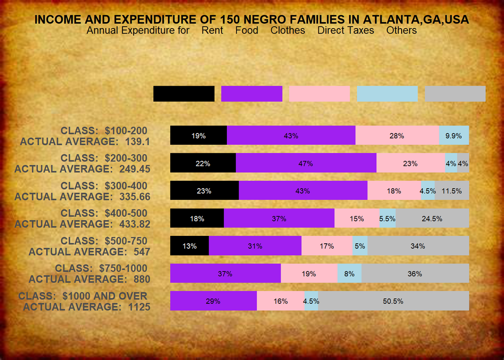

```r
# label: label-me-1
# Load libraries
library(ggplot2)
library(tidyr)
library(readr)
library(dplyr)
library(stringr)
library(tinytex)
library(jpeg)
library(grid)
library(scales)



library(cowplot)

# Load the background image
bg_img <- readJPEG("C:/Users/Reliance/Desktop/dataviz/hw-03/parchment.jpeg")

# Load and prepare the data
data <- read_csv("C:/Users/Reliance/Desktop/dataviz/hw-03/income.csv")
income_long <- data %>%
  pivot_longer(cols = Rent:Other, names_to = "Category", values_to = "Expenditure") %>%
  mutate(Category = factor(Category, levels = c("Rent", "Food", "Clothes", "Tax", "Other"), ordered = TRUE)) %>%
  mutate(Class_Label = paste("CLASS: ", Class, "\nACTUAL AVERAGE: ", Average_Income))

# Calculate total expenditure for each class
total_expenditure <- income_long %>%
  group_by(Class_Label) %>%
  summarise(Total = sum(Expenditure), .groups = 'drop')

# Join total expenditure back to income_long
income_long <- income_long %>%
  left_join(total_expenditure, by = "Class_Label") %>%
  mutate(Percentage = (Expenditure / Total) * 100)

# Define category colors
category_colors <- c(
  Rent = "black",
  Food = "purple",
  Clothes = "pink",
  Tax = "lightblue",
  Other = "grey"
)

# Create the main plot
p <- ggplot(income_long, aes(x = Expenditure, y = reorder(Class_Label, -Average_Income), fill = Category)) +
  geom_bar(stat = "identity", position = position_stack(reverse = TRUE), width = 0.7) +
  geom_text(aes(label = ifelse(Percentage >= 1.5, paste0(round(Percentage, 1), "%"), "")),
            position = position_stack(reverse = TRUE, vjust = 0.5), size = 2.5,
            color = ifelse(income_long$Category == "Rent", "white", "black")) +
  scale_fill_manual(values = category_colors) +
  theme_minimal() +
  theme(
    panel.background = element_rect(fill = "transparent", color = NA),
    panel.grid.major = element_blank(),
    panel.grid.minor = element_blank(),
    axis.title.y = element_blank(),
    axis.text.y = element_text(size = 10, face = "bold"),
    axis.text.x = element_blank(),
    axis.ticks.x = element_blank(),
    legend.position = "top",
    legend.title = element_blank(),
    axis.title.x = element_blank(),
    legend.text = element_blank(),
    legend.key.width = unit(2.2, "cm"),
    legend.spacing.x = unit(0, "cm"),
    plot.margin = margin(t = 80, r = 20, b = 40, l = 20),
    plot.caption = element_text(hjust = 0.5)
  ) +
  guides(fill = guide_legend(ncol = 5, byrow = TRUE))

# Title and subtitle annotations
title <- ggdraw() +
  draw_label("INCOME AND EXPENDITURE OF 150 NEGRO FAMILIES IN ATLANTA,GA,USA",
             fontface = 'bold', x = 0.5, y = 0.65, hjust = 0.5, size = 12) +
  draw_label("Annual Expenditure for    Rent    Food    Clothes    Direct Taxes    Others",
             x = 0.5, y = 0.45, hjust = 0.5, size = 10)

# Combine title, subtitle, background, and main plot
final_plot <- ggdraw() +
  draw_grob(rasterGrob(bg_img, width = unit(1, "npc"), height = unit(1, "npc"))) +
  draw_plot(title, x = 0, y = 0.85, width = 1, height = 0.15) + # Adjust title positioning
  draw_plot(p)

# Display the final plot
print(final_plot)
```

Interpretion: This R code creates a historical-style chart that shows how different income classes in Atlanta spent their money on categories like rent, food, clothes, taxes, and other expenses. It processes the data to calculate how much of each class’s total income went to each category, and then displays this using a colorful stacked bar chart. The chart uses a parchment paper background and adds a bold title and subtitle to match the style of W.E.B. Du Bois’s original 1900 design. Each bar represents a class, and percentage labels appear for spending categories that take up more than 1.5% of the budget, making it easy to compare spending habits across income levels.

[output not shown]

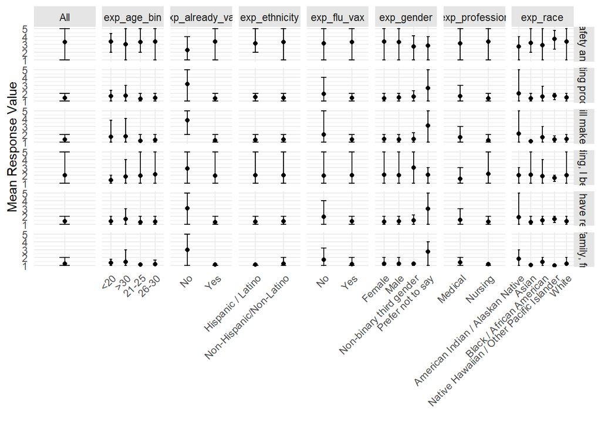

Interpretion: This plot visualizes how different demographic and experiential groups responded to COVID-19 vaccine-related survey questions, using mean Likert-scale ratings and error bars spanning the 10th to 90th percentiles. Each point represents the average response for a specific subgroup (e.g., Female, Nursing, or Age 21–25) to a given question, allowing us to compare attitudes across groups. For instance, we can observe whether trust in vaccine information or concern about side effects varies by age, gender, or professional background. The inclusion of overall averages (“All”) provides a baseline for comparison. Overall, the plot highlights both the central tendencies and variability in vaccine perceptions across key explanatory variables.

## 4 - COVID survey - re-reconstruct

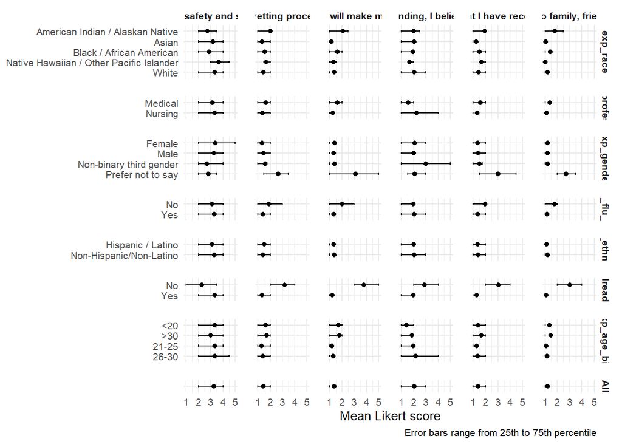

```r
library(tidyverse)
# Recalculate summary statistics with 25th and 75th percentiles
covid_survey_summary_iqr <- covid_survey_longer %>%
  group_by(explanatory, explanatory_value, response) %>%
  summarise(
    mean = mean(response_value, na.rm = TRUE),
    low = quantile(response_value, 0.25, na.rm = TRUE),
    high = quantile(response_value, 0.75, na.rm = TRUE),
    .groups = "drop"
  )

# Add "All" category (unconditioned summary stats)
covid_survey_summary_all_iqr <- covid_survey_longer %>%
  group_by(response) %>%
  summarise(
    mean = mean(response_value, na.rm = TRUE),
    low = quantile(response_value, 0.25, na.rm = TRUE),
    high = quantile(response_value, 0.75, na.rm = TRUE),
    explanatory = "All",
    explanatory_value = factor(""),
    .groups = "drop"
  )

# Combine both
covid_survey_summary_stats_iqr <- bind_rows(
  covid_survey_summary_all_iqr,
  covid_survey_summary_iqr
)

# Define readable labels again
response_labels <- c(
  resp_safety = "Based on my understanding, I believe the vaccine is safe",
  resp_feel_safe_at_work = "Getting the vaccine will make me feel safer at work",
  resp_concern_safety = "I am concerned about the safety and side effects of the vaccine",
  resp_confidence_science = "I am confident in the scientific vetting process for the new COVID vaccines",
  resp_trust_info = "I trust the information that I have received about the vaccines",
  resp_will_recommend = "I will recommend the vaccine to family, friends, and community members"
)

explanatory_labels <- c(
  exp_age_bin = "Age",
  exp_gender = "Gender",
  exp_race = "Race",
  exp_ethnicity = "Ethnicity",
  exp_profession = "Profession",
  exp_already_vax = "Had COVID vaccine",
  exp_flu_vax = "Had flu vaccine this year",
  All = "All"
)

# Plot using IQR (25th–75th)
ggplot(covid_survey_summary_stats_iqr, aes(x = mean, y = fct_rev(explanatory_value))) +
  geom_point() +
  geom_errorbarh(aes(xmin = low, xmax = high), height = 0.2) +
  facet_grid(
    fct_rev(explanatory) ~ response,
    scales = "free_y",
    space = "free_y",
    labeller = labeller(
      response = response_labels,
      explanatory = explanatory_labels
    )
  ) +
  scale_x_continuous(breaks = 1:5) +
  labs(
    x = "Mean Likert score",
    y = NULL,
    caption = "Error bars range from 25th to 75th percentile"
  ) +
  theme_minimal(base_size = 10) +
  theme(
    strip.text = element_text(face = "bold"),
    panel.spacing = unit(1, "lines")
  )
```

Interpretion: When using the 25th and 75th percentiles instead of the 10th and 90th, the error bars in the plot become noticeably narrower. This change reduces the appearance of variability, helping focus on the core distribution of opinions rather than outliers. While the overall trends across groups remain consistent, this version more accurately reflects the middle range of responses, avoiding possible exaggeration caused by extreme values in the original plot.

## 5 - COVID survey - another view

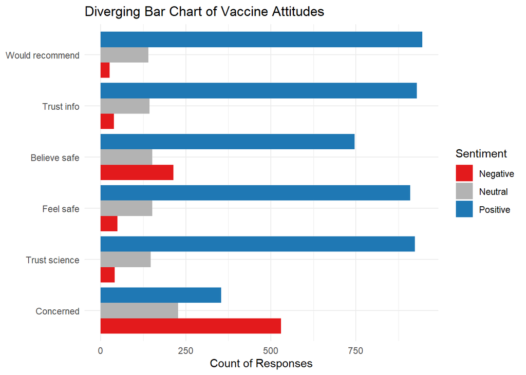

```r
# Load required libraries
library(tidyverse)
library(forcats)
library(ggplot2)
# Prepare Likert-style sentiment data
likert_data <- covid_survey %>%
  select(starts_with("resp_")) %>%
  pivot_longer(everything(), names_to = "question", values_to = "response") %>%
  mutate(
    question = fct_recode(question,
      "Believe safe" = "resp_safety",
      "Trust science" = "resp_confidence_science",
      "Concerned" = "resp_concern_safety",
      "Feel safe" = "resp_feel_safe_at_work",
      "Would recommend" = "resp_will_recommend",
      "Trust info" = "resp_trust_info"
    ),
    sentiment = case_when(
      response < 3 ~ "Positive",
      response > 3 ~ "Negative",
      TRUE ~ "Neutral"
    )
  )

# Plot diverging bar chart
ggplot(likert_data, aes(x = question, fill = sentiment)) +
  geom_bar(position = "dodge") +
  scale_fill_manual(values = c("Positive" = "#1f78b4", "Negative" = "#e31a1c", "Neutral" = "gray70")) +
  coord_flip() +
  labs(
    title = "Diverging Bar Chart of Vaccine Attitudes",
    x = NULL,
    y = "Count of Responses",
    fill = "Sentiment"
  ) +
  theme_minimal()
```

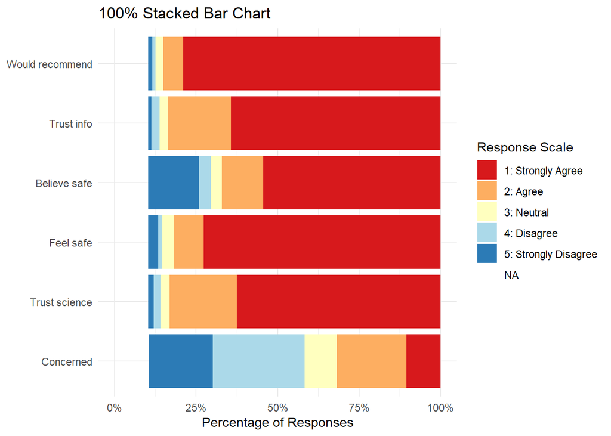

```r
ggplot(likert_data, aes(x = question, fill = factor(response))) +
  geom_bar(position = "fill") +
  scale_fill_brewer(palette = "RdYlBu",
    labels = c("1: Strongly Agree", "2: Agree", "3: Neutral",
               "4: Disagree", "5: Strongly Disagree")) +
  scale_y_continuous(labels = scales::percent) +
  coord_flip() +
  labs(
    title = "100% Stacked Bar Chart",
    x = NULL,
    y = "Percentage of Responses",
    fill = "Response Scale"
  ) +
  theme_minimal()
```

100% Stacked Bar: This chart displays the proportional breakdown of each response option by question, offering a normalized view of response percentages. It effectively shows the composition of response categories within each question.